# Lab 2 - Daryl Kay - DS202 2/19

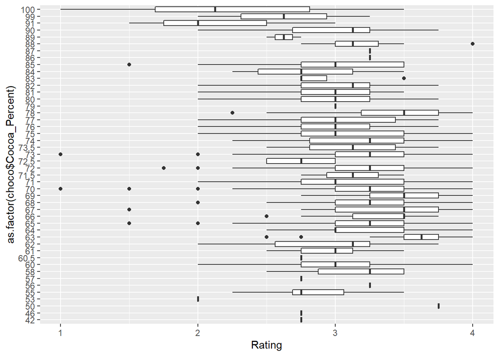

```r
ggplot(choco, aes(x=as.factor(choco$Cocoa_Percent), y=Rating)) + geom_boxplot() + coord_flip()
```

Just looking at the numerical data, we can see that the data doesn’t seem to have correlation. However, upon further inspection on the boxplot graph, we can see that there is a correlation. The ratings for the lower percent of cacoa and the highest percent seem to be the lowest. The higher ratings are found around the middle of the graph

```r
origin_rating <- aggregate.data.frame(choco$Rating, by=list(choco$Bean_Origin), mean)
origin_rating[order(-origin_rating$x),]
```

```
##                  Group.1        x
## 56                Tobago 3.625000
## 44   Sao Tome & Principe 3.500000
## 46       Solomon Islands 3.450000
## 11                 Congo 3.318182
## 55              Thailand 3.300000
## 13                  Cuba 3.291667
## 22             Guatemala 3.273585
## 23                 Haiti 3.270833
## 37      Papua New Guinea 3.270408
## 30            Madagascar 3.260736
## 63               Vietnam 3.253906
## 7                 Brazil 3.253333
## 1              Australia 3.250000
## 6                 Bolvia 3.250000
```

[output cut: 49 more lines]

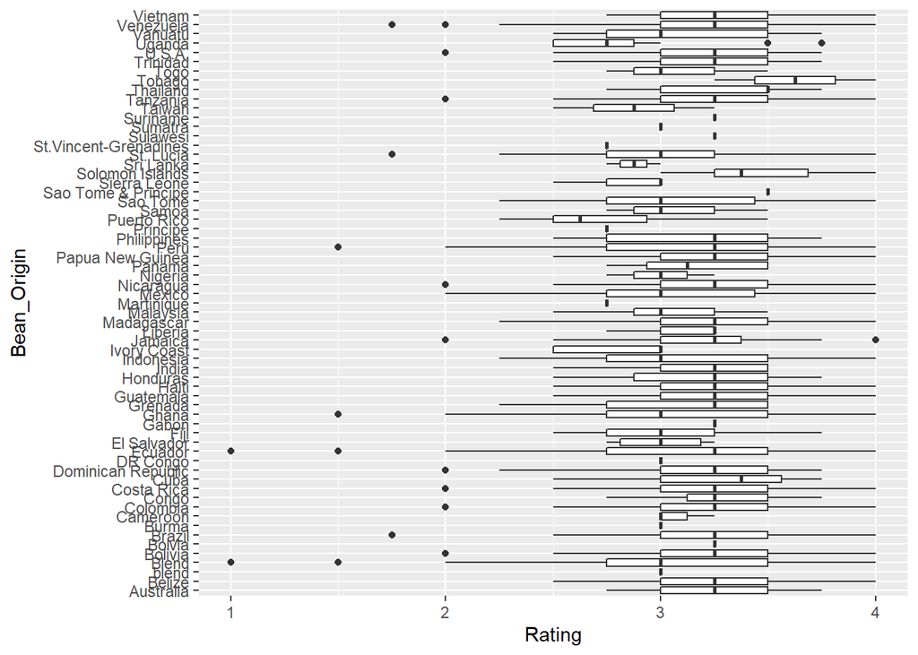

```r
ggplot(choco, aes(x=Bean_Origin, y=Rating)) + geom_boxplot() + coord_flip()
```

Beans from different origins did have a different rating which could happen for a number of reasons. Further research may need to be done to find this reason. Beans from Tobago, Sao Tome & Principe, the Solomon Islands and the Congo had the highest rated beans while places like St.Vincent-Grenadines, Puerta Rico, and Principe had the lowest rated beans.

#### First Analysis

I wanted to find out whether the date had anything to do with the rating of chocolate. I will compare the date the rating was made as well as the rating itself.

```r
date_rating <- aggregate.data.frame(choco$Rating, by=list(choco$Date), mean)
date_rating
```

```
##    Group.1        x
## 1     2006 3.004032
## 2     2007 3.102740
## 3     2008 3.000000
## 4     2009 3.073171
## 5     2010 3.152273
## 6     2011 3.257669
## 7     2012 3.180412
## 8     2013 3.197011
## 9     2014 3.189271
## 10    2015 3.244718
## 11    2016 3.226027
## 12    2017 3.361905
## 13    2018 3.192325
## 14    2019 3.133333
## 15    2020 3.159091
```

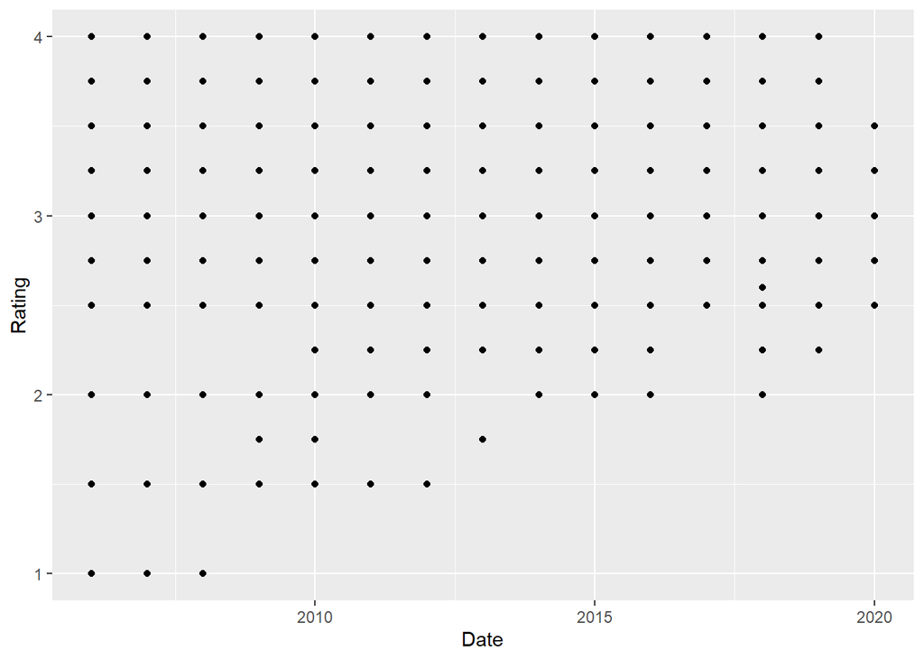

```r
ggplot(choco, aes(x=Date, y=Rating)) + geom_point()
```

While we don’t know the reason behind it, from the graph we can see that the lower ratings started to disapear as the years went on. Further testing will be needed to solidify the hypothesis but this could be because the chocolate bars with the lower rating went out of business over time because they didn’t deliver a quality product.

#### Second Analysis

I want to find out whether the bean origin has anything to do with the cocoa percent in the chocolate bars. They may decide to use a higher cocoa or lower cocoa percent depending on the origin of the bean.

```r
Cocoa_percent_origin <- aggregate.data.frame(choco$Cocoa_Percent, by=list(choco$Bean_Origin), mean)
Cocoa_percent_origin[order(-Cocoa_percent_origin$x),]
```

```
##                  Group.1        x
## 42                 Samoa 82.33333
## 40              Principe 77.00000
## 3                  blend 75.00000
## 19                 Gabon 75.00000
## 44   Sao Tome & Principe 75.00000
## 13                  Cuba 74.33333
## 16               Ecuador 73.30425
## 18                  Fiji 72.86667
## 2                 Belize 72.86567
## 24              Honduras 72.73913
## 63               Vietnam 72.60938
## 47             Sri Lanka 72.50000
## 26             Indonesia 72.33333
## 54              Tanzania 72.26562
```

[output cut: 49 more lines]

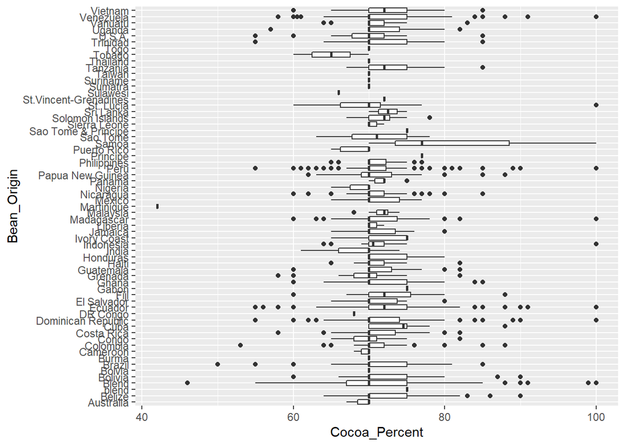

```r
ggplot(choco, aes(x=Bean_Origin, y=Cocoa_Percent)) + geom_boxplot() + coord_flip()
```

While most of the origins are around the 65-75% of cocoa, there was a country that stood out as an outlier itself. Beans from Samoa were made into 82.3% bars on average. While there are plenty of outlier points on the boxplot, Somoa has a boxplot shifted a lot higher than the other origins